# Risk Factor Analysis

## Outcome Variable

**Outcome Variable:** wast_rec90d

## Predictor Variables

**Intervention Variable:** birthlen

**Adjustment Set:**

unadjusted

## Stratifying Variables

The analysis was stratified on these variable(s):

- agecat
- studyid
- country

## Data Summary

| agecat | studyid | country | birthlen | wast_rec90d | n_cell | n |
| --- | --- | --- | --- | --- | --- | --- |
| 0-24 months | CMC-V-BCS-2002 | INDIA | >=50 cm | 0 | 3 | 88 |
| 0-24 months | CMC-V-BCS-2002 | INDIA | >=50 cm | 1 | 3 | 88 |
| 0-24 months | CMC-V-BCS-2002 | INDIA | <48 cm | 0 | 19 | 88 |
| 0-24 months | CMC-V-BCS-2002 | INDIA | <48 cm | 1 | 27 | 88 |
| 0-24 months | CMC-V-BCS-2002 | INDIA | [48-50) cm | 0 | 9 | 88 |
| 0-24 months | CMC-V-BCS-2002 | INDIA | [48-50) cm | 1 | 27 | 88 |
| 0-24 months | CMIN | BANGLADESH | >=50 cm | 0 | 1 | 12 |
| 0-24 months | CMIN | BANGLADESH | >=50 cm | 1 | 0 | 12 |
| 0-24 months | CMIN | BANGLADESH | <48 cm | 0 | 4 | 12 |
| 0-24 months | CMIN | BANGLADESH | <48 cm | 1 | 3 | 12 |
| 0-24 months | CMIN | BANGLADESH | [48-50) cm | 0 | 0 | 12 |
| 0-24 months | CMIN | BANGLADESH | [48-50) cm | 1 | 4 | 12 |
| 0-24 months | COHORTS | GUATEMALA | >=50 cm | 0 | 59 | 295 |
| 0-24 months | COHORTS | GUATEMALA | >=50 cm | 1 | 118 | 295 |
| 0-24 months | COHORTS | GUATEMALA | <48 cm | 0 | 33 | 295 |
| 0-24 months | COHORTS | GUATEMALA | <48 cm | 1 | 11 | 295 |
| 0-24 months | COHORTS | GUATEMALA | [48-50) cm | 0 | 35 | 295 |
| 0-24 months | COHORTS | GUATEMALA | [48-50) cm | 1 | 39 | 295 |
| 0-24 months | COHORTS | INDIA | >=50 cm | 0 | 338 | 2497 |
| 0-24 months | COHORTS | INDIA | >=50 cm | 1 | 186 | 2497 |
| 0-24 months | COHORTS | INDIA | <48 cm | 0 | 862 | 2497 |
| 0-24 months | COHORTS | INDIA | <48 cm | 1 | 211 | 2497 |
| 0-24 months | COHORTS | INDIA | [48-50) cm | 0 | 653 | 2497 |
| 0-24 months | COHORTS | INDIA | [48-50) cm | 1 | 247 | 2497 |
| 0-24 months | COHORTS | PHILIPPINES | >=50 cm | 0 | 190 | 1686 |
| 0-24 months | COHORTS | PHILIPPINES | >=50 cm | 1 | 423 | 1686 |
| 0-24 months | COHORTS | PHILIPPINES | <48 cm | 0 | 218 | 1686 |
| 0-24 months | COHORTS | PHILIPPINES | <48 cm | 1 | 259 | 1686 |
| 0-24 months | COHORTS | PHILIPPINES | [48-50) cm | 0 | 255 | 1686 |
| 0-24 months | COHORTS | PHILIPPINES | [48-50) cm | 1 | 341 | 1686 |

[output cut: 420 more lines]

The following strata were considered:

- agecat: 0-24 months, studyid: CMC-V-BCS-2002, country: INDIA
- agecat: 0-24 months, studyid: CMIN, country: BANGLADESH
- agecat: 0-24 months, studyid: COHORTS, country: GUATEMALA
- agecat: 0-24 months, studyid: COHORTS, country: INDIA
- agecat: 0-24 months, studyid: COHORTS, country: PHILIPPINES
- agecat: 0-24 months, studyid: EE, country: PAKISTAN
- agecat: 0-24 months, studyid: GMS-Nepal, country: NEPAL
- agecat: 0-24 months, studyid: IRC, country: INDIA
- agecat: 0-24 months, studyid: JiVitA-3, country: BANGLADESH
- agecat: 0-24 months, studyid: JiVitA-4, country: BANGLADESH
- agecat: 0-24 months, studyid: Keneba, country: GAMBIA
- agecat: 0-24 months, studyid: MAL-ED, country: BANGLADESH
- agecat: 0-24 months, studyid: MAL-ED, country: BRAZIL
- agecat: 0-24 months, studyid: MAL-ED, country: INDIA
- agecat: 0-24 months, studyid: MAL-ED, country: NEPAL
- agecat: 0-24 months, studyid: MAL-ED, country: PERU
- agecat: 0-24 months, studyid: MAL-ED, country: SOUTH AFRICA
- agecat: 0-24 months, studyid: MAL-ED, country: TANZANIA, UNITED REPUBLIC OF
- agecat: 0-24 months, studyid: NIH-Birth, country: BANGLADESH
- agecat: 0-24 months, studyid: NIH-Crypto, country: BANGLADESH
- agecat: 0-24 months, studyid: PROBIT, country: BELARUS
- agecat: 0-24 months, studyid: PROVIDE, country: BANGLADESH
- agecat: 0-24 months, studyid: ResPak, country: PAKISTAN
- agecat: 0-24 months, studyid: SAS-CompFeed, country: INDIA
- agecat: 0-24 months, studyid: ZVITAMBO, country: ZIMBABWE
- agecat: 0-6 months, studyid: CMC-V-BCS-2002, country: INDIA
- agecat: 0-6 months, studyid: CMIN, country: BANGLADESH
- agecat: 0-6 months, studyid: COHORTS, country: GUATEMALA
- agecat: 0-6 months, studyid: COHORTS, country: INDIA
- agecat: 0-6 months, studyid: COHORTS, country: PHILIPPINES
- agecat: 0-6 months, studyid: EE, country: PAKISTAN
- agecat: 0-6 months, studyid: GMS-Nepal, country: NEPAL
- agecat: 0-6 months, studyid: IRC, country: INDIA
- agecat: 0-6 months, studyid: JiVitA-3, country: BANGLADESH
- agecat: 0-6 months, studyid: JiVitA-4, country: BANGLADESH
- agecat: 0-6 months, studyid: Keneba, country: GAMBIA
- agecat: 0-6 months, studyid: MAL-ED, country: BANGLADESH
- agecat: 0-6 months, studyid: MAL-ED, country: BRAZIL
- agecat: 0-6 months, studyid: MAL-ED, country: INDIA
- agecat: 0-6 months, studyid: MAL-ED, country: NEPAL
- agecat: 0-6 months, studyid: MAL-ED, country: PERU
- agecat: 0-6 months, studyid: MAL-ED, country: SOUTH AFRICA
- agecat: 0-6 months, studyid: MAL-ED, country: TANZANIA, UNITED REPUBLIC OF
- agecat: 0-6 months, studyid: NIH-Birth, country: BANGLADESH
- agecat: 0-6 months, studyid: NIH-Crypto, country: BANGLADESH
- agecat: 0-6 months, studyid: PROBIT, country: BELARUS
- agecat: 0-6 months, studyid: PROVIDE, country: BANGLADESH
- agecat: 0-6 months, studyid: ResPak, country: PAKISTAN
- agecat: 0-6 months, studyid: SAS-CompFeed, country: INDIA
- agecat: 0-6 months, studyid: ZVITAMBO, country: ZIMBABWE
- agecat: 6-24 months, studyid: CMC-V-BCS-2002, country: INDIA
- agecat: 6-24 months, studyid: CMIN, country: BANGLADESH
- agecat: 6-24 months, studyid: COHORTS, country: GUATEMALA
- agecat: 6-24 months, studyid: COHORTS, country: INDIA
- agecat: 6-24 months, studyid: COHORTS, country: PHILIPPINES
- agecat: 6-24 months, studyid: EE, country: PAKISTAN
- agecat: 6-24 months, studyid: GMS-Nepal, country: NEPAL
- agecat: 6-24 months, studyid: IRC, country: INDIA
- agecat: 6-24 months, studyid: JiVitA-3, country: BANGLADESH
- agecat: 6-24 months, studyid: JiVitA-4, country: BANGLADESH
- agecat: 6-24 months, studyid: Keneba, country: GAMBIA
- agecat: 6-24 months, studyid: MAL-ED, country: BANGLADESH
- agecat: 6-24 months, studyid: MAL-ED, country: BRAZIL
- agecat: 6-24 months, studyid: MAL-ED, country: INDIA
- agecat: 6-24 months, studyid: MAL-ED, country: NEPAL
- agecat: 6-24 months, studyid: MAL-ED, country: PERU
- agecat: 6-24 months, studyid: MAL-ED, country: SOUTH AFRICA
- agecat: 6-24 months, studyid: MAL-ED, country: TANZANIA, UNITED REPUBLIC OF
- agecat: 6-24 months, studyid: NIH-Birth, country: BANGLADESH
- agecat: 6-24 months, studyid: NIH-Crypto, country: BANGLADESH
- agecat: 6-24 months, studyid: PROBIT, country: BELARUS
- agecat: 6-24 months, studyid: PROVIDE, country: BANGLADESH
- agecat: 6-24 months, studyid: ResPak, country: PAKISTAN
- agecat: 6-24 months, studyid: SAS-CompFeed, country: INDIA
- agecat: 6-24 months, studyid: ZVITAMBO, country: ZIMBABWE

### Dropped Strata

Some strata were dropped due to rare outcomes:

- agecat: 0-24 months, studyid: CMC-V-BCS-2002, country: INDIA
- agecat: 0-24 months, studyid: CMIN, country: BANGLADESH
- agecat: 0-24 months, studyid: MAL-ED, country: BRAZIL
- agecat: 0-24 months, studyid: MAL-ED, country: INDIA
- agecat: 0-24 months, studyid: MAL-ED, country: NEPAL
- agecat: 0-24 months, studyid: MAL-ED, country: PERU
- agecat: 0-24 months, studyid: MAL-ED, country: SOUTH AFRICA
- agecat: 0-24 months, studyid: MAL-ED, country: TANZANIA, UNITED REPUBLIC OF
- agecat: 0-24 months, studyid: ResPak, country: PAKISTAN
- agecat: 0-6 months, studyid: CMC-V-BCS-2002, country: INDIA
- agecat: 0-6 months, studyid: CMIN, country: BANGLADESH
- agecat: 0-6 months, studyid: EE, country: PAKISTAN
- agecat: 0-6 months, studyid: MAL-ED, country: BANGLADESH
- agecat: 0-6 months, studyid: MAL-ED, country: BRAZIL
- agecat: 0-6 months, studyid: MAL-ED, country: INDIA
- agecat: 0-6 months, studyid: MAL-ED, country: NEPAL
- agecat: 0-6 months, studyid: MAL-ED, country: PERU
- agecat: 0-6 months, studyid: MAL-ED, country: SOUTH AFRICA
- agecat: 0-6 months, studyid: MAL-ED, country: TANZANIA, UNITED REPUBLIC OF
- agecat: 0-6 months, studyid: NIH-Crypto, country: BANGLADESH
- agecat: 0-6 months, studyid: PROBIT, country: BELARUS
- agecat: 0-6 months, studyid: ResPak, country: PAKISTAN
- agecat: 6-24 months, studyid: CMC-V-BCS-2002, country: INDIA
- agecat: 6-24 months, studyid: CMIN, country: BANGLADESH
- agecat: 6-24 months, studyid: COHORTS, country: GUATEMALA
- agecat: 6-24 months, studyid: COHORTS, country: INDIA
- agecat: 6-24 months, studyid: EE, country: PAKISTAN
- agecat: 6-24 months, studyid: JiVitA-3, country: BANGLADESH
- agecat: 6-24 months, studyid: MAL-ED, country: BANGLADESH
- agecat: 6-24 months, studyid: MAL-ED, country: BRAZIL
- agecat: 6-24 months, studyid: MAL-ED, country: INDIA
- agecat: 6-24 months, studyid: MAL-ED, country: NEPAL
- agecat: 6-24 months, studyid: MAL-ED, country: PERU
- agecat: 6-24 months, studyid: MAL-ED, country: SOUTH AFRICA
- agecat: 6-24 months, studyid: MAL-ED, country: TANZANIA, UNITED REPUBLIC OF
- agecat: 6-24 months, studyid: NIH-Crypto, country: BANGLADESH
- agecat: 6-24 months, studyid: PROBIT, country: BELARUS
- agecat: 6-24 months, studyid: PROVIDE, country: BANGLADESH
- agecat: 6-24 months, studyid: ResPak, country: PAKISTAN

## Methods Detail

We’re interested in the causal parameters $E[Y_a]$ for all values of $a \in \mathcal{A}$. These parameters represent the mean outcome if, possibly contrary to fact, we intervened to set all units to have $A=a$. Under the randomization and positivity assumptions, these are identified by the statistical parameters $\psi_a=E_W[E_{Y|A,W}(Y|A=a,W)]$. In addition, we’re interested in the mean of $Y$, $E[Y]$ under no intervention (the observed mean). We will estimate these parameters by using SuperLearner to fit the relevant likelihood factors – $E_{Y|A,W}(Y|A=a,W)$ and $p(A=a|W)$, and then updating our likelihood fit using a joint TMLE.

For unadjusted analyses ($W=\{\}$), initial likelihoods were estimated using Lrnr_glm to estimate the simple $E(Y|A)$ and Lrnr_mean to estimate $p(A)$. For adjusted analyses, a small library containing Lrnr_glmnet, Lrnr_xgboost, and Lrnr_mean was used.

Having estimated these parameters, we will then use the delta method to estimate relative risks and attributable risks relative to a prespecified baseline level of $A$.

# Results Detail

## Results Plots

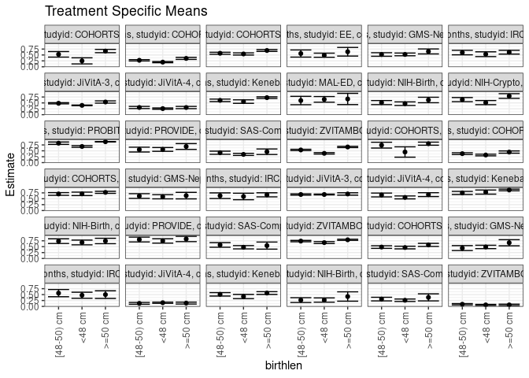

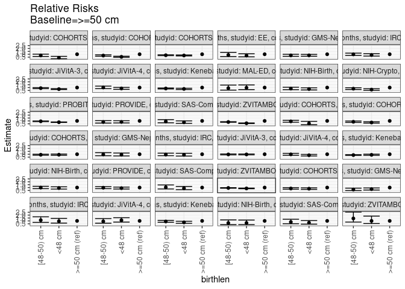

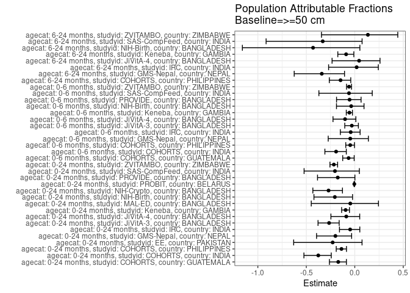

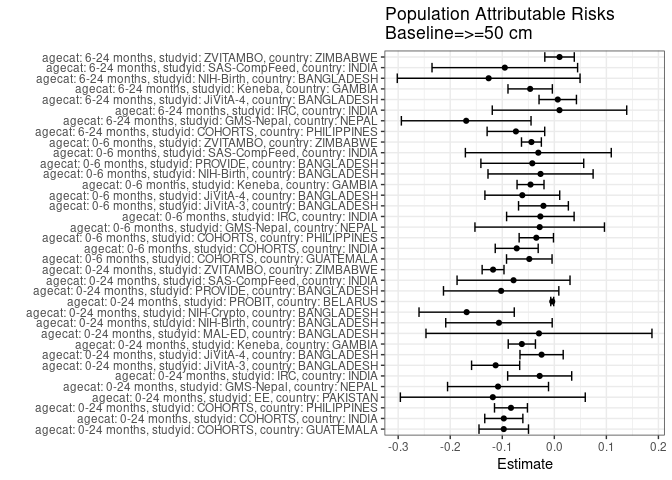

## Results Table

### Parameter: TSM

| agecat | studyid | country | intervention_level | baseline_level | estimate | ci_lower | ci_upper |
| --- | --- | --- | --- | --- | --- | --- | --- |
| 0-24 months | COHORTS | GUATEMALA | >=50 cm | NA | 0.6666667 | 0.5971625 | 0.7361708 |
| 0-24 months | COHORTS | GUATEMALA | <48 cm | NA | 0.2500000 | 0.1204813 | 0.3795187 |
| 0-24 months | COHORTS | GUATEMALA | [48-50) cm | NA | 0.5270270 | 0.4094678 | 0.6445863 |
| 0-24 months | COHORTS | INDIA | >=50 cm | NA | 0.3549618 | 0.3125506 | 0.3973731 |
| 0-24 months | COHORTS | INDIA | <48 cm | NA | 0.1966449 | 0.1732556 | 0.2200342 |
| 0-24 months | COHORTS | INDIA | [48-50) cm | NA | 0.2744444 | 0.2452239 | 0.3036650 |
| 0-24 months | COHORTS | PHILIPPINES | >=50 cm | NA | 0.6900489 | 0.6512862 | 0.7288117 |
| 0-24 months | COHORTS | PHILIPPINES | <48 cm | NA | 0.5429769 | 0.4977756 | 0.5881783 |
| 0-24 months | COHORTS | PHILIPPINES | [48-50) cm | NA | 0.5721477 | 0.5298466 | 0.6144487 |
| 0-24 months | EE | PAKISTAN | >=50 cm | NA | 0.6363636 | 0.4530706 | 0.8196567 |
| 0-24 months | EE | PAKISTAN | <48 cm | NA | 0.4904459 | 0.4037290 | 0.5771627 |
| 0-24 months | EE | PAKISTAN | [48-50) cm | NA | 0.5609756 | 0.4092507 | 0.7127005 |
| 0-24 months | GMS-Nepal | NEPAL | >=50 cm | NA | 0.6494845 | 0.5446622 | 0.7543069 |
| 0-24 months | GMS-Nepal | NEPAL | <48 cm | NA | 0.5232558 | 0.4650941 | 0.5814175 |
| 0-24 months | GMS-Nepal | NEPAL | [48-50) cm | NA | 0.5200000 | 0.4460846 | 0.5939154 |
| 0-24 months | IRC | INDIA | >=50 cm | NA | 0.6172840 | 0.5377766 | 0.6967913 |
| 0-24 months | IRC | INDIA | <48 cm | NA | 0.5327103 | 0.4316629 | 0.6337577 |
| 0-24 months | IRC | INDIA | [48-50) cm | NA | 0.6016949 | 0.5069499 | 0.6964399 |
| 0-24 months | JiVitA-3 | BANGLADESH | >=50 cm | NA | 0.5379147 | 0.4900041 | 0.5858253 |
| 0-24 months | JiVitA-3 | BANGLADESH | <48 cm | NA | 0.3947724 | 0.3804571 | 0.4090877 |
| 0-24 months | JiVitA-3 | BANGLADESH | [48-50) cm | NA | 0.4835901 | 0.4581386 | 0.5090415 |
| 0-24 months | JiVitA-4 | BANGLADESH | >=50 cm | NA | 0.3041363 | 0.2556895 | 0.3525830 |
| 0-24 months | JiVitA-4 | BANGLADESH | <48 cm | NA | 0.2582988 | 0.2303553 | 0.2862422 |
| 0-24 months | JiVitA-4 | BANGLADESH | [48-50) cm | NA | 0.3063291 | 0.2600547 | 0.3526035 |
| 0-24 months | Keneba | GAMBIA | >=50 cm | NA | 0.7228178 | 0.6878370 | 0.7577986 |
| 0-24 months | Keneba | GAMBIA | <48 cm | NA | 0.5555556 | 0.4818614 | 0.6292497 |
| 0-24 months | Keneba | GAMBIA | [48-50) cm | NA | 0.6082192 | 0.5552888 | 0.6611496 |
| 0-24 months | MAL-ED | BANGLADESH | >=50 cm | NA | 0.6666667 | 0.4286826 | 0.9046507 |
| 0-24 months | MAL-ED | BANGLADESH | <48 cm | NA | 0.6500000 | 0.5293253 | 0.7706747 |
| 0-24 months | MAL-ED | BANGLADESH | [48-50) cm | NA | 0.6000000 | 0.4226014 | 0.7773986 |

[output cut: 78 more lines]

### Parameter: E(Y)

| agecat | studyid | country | intervention_level | baseline_level | estimate | ci_lower | ci_upper |
| --- | --- | --- | --- | --- | --- | --- | --- |
| 0-24 months | COHORTS | GUATEMALA | NA | NA | 0.5694915 | 0.5120418 | 0.6269413 |
| 0-24 months | COHORTS | INDIA | NA | NA | 0.2579095 | 0.2406335 | 0.2751855 |
| 0-24 months | COHORTS | PHILIPPINES | NA | NA | 0.6067616 | 0.5822457 | 0.6312775 |
| 0-24 months | EE | PAKISTAN | NA | NA | 0.5181818 | 0.4466550 | 0.5897087 |
| 0-24 months | GMS-Nepal | NEPAL | NA | NA | 0.5413417 | 0.4990070 | 0.5836763 |
| 0-24 months | IRC | INDIA | NA | NA | 0.5891473 | 0.5364145 | 0.6418800 |
| 0-24 months | JiVitA-3 | BANGLADESH | NA | NA | 0.4251535 | 0.4129986 | 0.4373083 |
| 0-24 months | JiVitA-4 | BANGLADESH | NA | NA | 0.2796610 | 0.2580570 | 0.3012650 |
| 0-24 months | Keneba | GAMBIA | NA | NA | 0.6604082 | 0.6324757 | 0.6883406 |
| 0-24 months | MAL-ED | BANGLADESH | NA | NA | 0.6371681 | 0.5446961 | 0.7296402 |
| 0-24 months | NIH-Birth | BANGLADESH | NA | NA | 0.5171569 | 0.4657250 | 0.5685888 |
| 0-24 months | NIH-Crypto | BANGLADESH | NA | NA | 0.6225806 | 0.5684562 | 0.6767051 |
| 0-24 months | PROBIT | BELARUS | NA | NA | 0.8806715 | 0.8711794 | 0.8901636 |
| 0-24 months | PROVIDE | BANGLADESH | NA | NA | 0.5811688 | 0.5245443 | 0.6377934 |
| 0-24 months | SAS-CompFeed | INDIA | NA | NA | 0.3831891 | 0.3479331 | 0.4184451 |
| 0-24 months | ZVITAMBO | ZIMBABWE | NA | NA | 0.5452017 | 0.5287719 | 0.5616314 |
| 0-6 months | COHORTS | GUATEMALA | NA | NA | 0.7547170 | 0.6968087 | 0.8126253 |
| 0-6 months | COHORTS | INDIA | NA | NA | 0.3748545 | 0.3519572 | 0.3977518 |
| 0-6 months | COHORTS | PHILIPPINES | NA | NA | 0.7363515 | 0.7047428 | 0.7679603 |
| 0-6 months | GMS-Nepal | NEPAL | NA | NA | 0.6045627 | 0.5449300 | 0.6641955 |
| 0-6 months | IRC | INDIA | NA | NA | 0.6398305 | 0.5770134 | 0.7026476 |
| 0-6 months | JiVitA-3 | BANGLADESH | NA | NA | 0.6818985 | 0.6673935 | 0.6964035 |
| 0-6 months | JiVitA-4 | BANGLADESH | NA | NA | 0.6130952 | 0.5705324 | 0.6556580 |
| 0-6 months | Keneba | GAMBIA | NA | NA | 0.8259325 | 0.7956783 | 0.8561867 |
| 0-6 months | NIH-Birth | BANGLADESH | NA | NA | 0.7142857 | 0.6541352 | 0.7744362 |
| 0-6 months | PROVIDE | BANGLADESH | NA | NA | 0.7837838 | 0.7252863 | 0.8422812 |
| 0-6 months | SAS-CompFeed | INDIA | NA | NA | 0.5147059 | 0.4610948 | 0.5683169 |
| 0-6 months | ZVITAMBO | ZIMBABWE | NA | NA | 0.7472178 | 0.7302477 | 0.7641880 |
| 6-24 months | COHORTS | PHILIPPINES | NA | NA | 0.5026738 | 0.4688037 | 0.5365439 |
| 6-24 months | GMS-Nepal | NEPAL | NA | NA | 0.4973545 | 0.4426760 | 0.5520330 |
| 6-24 months | IRC | INDIA | NA | NA | 0.5099338 | 0.4248374 | 0.5950302 |
| 6-24 months | JiVitA-4 | BANGLADESH | NA | NA | 0.1469194 | 0.1276367 | 0.1662021 |
| 6-24 months | Keneba | GAMBIA | NA | NA | 0.5196375 | 0.4788178 | 0.5604571 |
| 6-24 months | NIH-Birth | BANGLADESH | NA | NA | 0.2931937 | 0.2273732 | 0.3590142 |
| 6-24 months | SAS-CompFeed | INDIA | NA | NA | 0.2878465 | 0.2457514 | 0.3299415 |
| 6-24 months | ZVITAMBO | ZIMBABWE | NA | NA | 0.0741427 | 0.0585455 | 0.0897399 |

### Parameter: RR

| agecat | studyid | country | intervention_level | baseline_level | estimate | ci_lower | ci_upper |
| --- | --- | --- | --- | --- | --- | --- | --- |
| 0-24 months | COHORTS | GUATEMALA | >=50 cm | >=50 cm | 1.0000000 | 1.0000000 | 1.0000000 |
| 0-24 months | COHORTS | GUATEMALA | <48 cm | >=50 cm | 0.3750000 | 0.2210576 | 0.6361464 |
| 0-24 months | COHORTS | GUATEMALA | [48-50) cm | >=50 cm | 0.7905405 | 0.6179243 | 1.0113769 |
| 0-24 months | COHORTS | INDIA | >=50 cm | >=50 cm | 1.0000000 | 1.0000000 | 1.0000000 |
| 0-24 months | COHORTS | INDIA | <48 cm | >=50 cm | 0.5539889 | 0.4680435 | 0.6557162 |
| 0-24 months | COHORTS | INDIA | [48-50) cm | >=50 cm | 0.7731661 | 0.6588258 | 0.9073503 |
| 0-24 months | COHORTS | PHILIPPINES | >=50 cm | >=50 cm | 1.0000000 | 1.0000000 | 1.0000000 |
| 0-24 months | COHORTS | PHILIPPINES | <48 cm | >=50 cm | 0.7868673 | 0.7116838 | 0.8699932 |
| 0-24 months | COHORTS | PHILIPPINES | [48-50) cm | >=50 cm | 0.8291407 | 0.7555974 | 0.9098421 |
| 0-24 months | EE | PAKISTAN | >=50 cm | >=50 cm | 1.0000000 | 1.0000000 | 1.0000000 |
| 0-24 months | EE | PAKISTAN | <48 cm | >=50 cm | 0.7707006 | 0.5499261 | 1.0801077 |
| 0-24 months | EE | PAKISTAN | [48-50) cm | >=50 cm | 0.8815331 | 0.5935933 | 1.3091465 |
| 0-24 months | GMS-Nepal | NEPAL | >=50 cm | >=50 cm | 1.0000000 | 1.0000000 | 1.0000000 |
| 0-24 months | GMS-Nepal | NEPAL | <48 cm | >=50 cm | 0.8056478 | 0.6623210 | 0.9799907 |
| 0-24 months | GMS-Nepal | NEPAL | [48-50) cm | >=50 cm | 0.8006349 | 0.6457546 | 0.9926624 |
| 0-24 months | IRC | INDIA | >=50 cm | >=50 cm | 1.0000000 | 1.0000000 | 1.0000000 |
| 0-24 months | IRC | INDIA | <48 cm | >=50 cm | 0.8629907 | 0.6863366 | 1.0851131 |
| 0-24 months | IRC | INDIA | [48-50) cm | >=50 cm | 0.9747458 | 0.7951915 | 1.1948434 |
| 0-24 months | JiVitA-3 | BANGLADESH | >=50 cm | >=50 cm | 1.0000000 | 1.0000000 | 1.0000000 |
| 0-24 months | JiVitA-3 | BANGLADESH | <48 cm | >=50 cm | 0.7338941 | 0.6666067 | 0.8079736 |
| 0-24 months | JiVitA-3 | BANGLADESH | [48-50) cm | >=50 cm | 0.8990089 | 0.8106504 | 0.9969981 |
| 0-24 months | JiVitA-4 | BANGLADESH | >=50 cm | >=50 cm | 1.0000000 | 1.0000000 | 1.0000000 |
| 0-24 months | JiVitA-4 | BANGLADESH | <48 cm | >=50 cm | 0.8492863 | 0.7005305 | 1.0296300 |
| 0-24 months | JiVitA-4 | BANGLADESH | [48-50) cm | >=50 cm | 1.0072101 | 0.8086853 | 1.2544710 |
| 0-24 months | Keneba | GAMBIA | >=50 cm | >=50 cm | 1.0000000 | 1.0000000 | 1.0000000 |
| 0-24 months | Keneba | GAMBIA | <48 cm | >=50 cm | 0.7685970 | 0.6673859 | 0.8851570 |
| 0-24 months | Keneba | GAMBIA | [48-50) cm | >=50 cm | 0.8414558 | 0.7616573 | 0.9296147 |
| 0-24 months | MAL-ED | BANGLADESH | >=50 cm | >=50 cm | 1.0000000 | 1.0000000 | 1.0000000 |
| 0-24 months | MAL-ED | BANGLADESH | <48 cm | >=50 cm | 0.9750000 | 0.6519879 | 1.4580409 |
| 0-24 months | MAL-ED | BANGLADESH | [48-50) cm | >=50 cm | 0.9000000 | 0.5660784 | 1.4308972 |

[output cut: 78 more lines]

### Parameter: PAR

| agecat | studyid | country | intervention_level | baseline_level | estimate | ci_lower | ci_upper |
| --- | --- | --- | --- | --- | --- | --- | --- |
| 0-24 months | COHORTS | GUATEMALA | >=50 cm | NA | -0.0971751 | -0.1447216 | -0.0496286 |
| 0-24 months | COHORTS | INDIA | >=50 cm | NA | -0.0970523 | -0.1336540 | -0.0604507 |
| 0-24 months | COHORTS | PHILIPPINES | >=50 cm | NA | -0.0832874 | -0.1149303 | -0.0516444 |
| 0-24 months | EE | PAKISTAN | >=50 cm | NA | -0.1181818 | -0.2958163 | 0.0594526 |
| 0-24 months | GMS-Nepal | NEPAL | >=50 cm | NA | -0.1081429 | -0.2051291 | -0.0111566 |
| 0-24 months | IRC | INDIA | >=50 cm | NA | -0.0281367 | -0.0896721 | 0.0333988 |
| 0-24 months | JiVitA-3 | BANGLADESH | >=50 cm | NA | -0.1127612 | -0.1589864 | -0.0665360 |
| 0-24 months | JiVitA-4 | BANGLADESH | >=50 cm | NA | -0.0244752 | -0.0659980 | 0.0170475 |
| 0-24 months | Keneba | GAMBIA | >=50 cm | NA | -0.0624096 | -0.0885435 | -0.0362757 |
| 0-24 months | MAL-ED | BANGLADESH | >=50 cm | NA | -0.0294985 | -0.2465936 | 0.1875965 |
| 0-24 months | NIH-Birth | BANGLADESH | >=50 cm | NA | -0.1063725 | -0.2086407 | -0.0041044 |
| 0-24 months | NIH-Crypto | BANGLADESH | >=50 cm | NA | -0.1684641 | -0.2599633 | -0.0769649 |
| 0-24 months | PROBIT | BELARUS | >=50 cm | NA | -0.0040270 | -0.0068724 | -0.0011816 |
| 0-24 months | PROVIDE | BANGLADESH | >=50 cm | NA | -0.1021645 | -0.2129687 | 0.0086397 |
| 0-24 months | SAS-CompFeed | INDIA | >=50 cm | NA | -0.0783493 | -0.1868688 | 0.0301701 |
| 0-24 months | ZVITAMBO | ZIMBABWE | >=50 cm | NA | -0.1176943 | -0.1386864 | -0.0967021 |
| 0-6 months | COHORTS | GUATEMALA | >=50 cm | NA | -0.0480999 | -0.0918402 | -0.0043596 |
| 0-6 months | COHORTS | INDIA | >=50 cm | NA | -0.0722609 | -0.1135189 | -0.0310029 |
| 0-6 months | COHORTS | PHILIPPINES | >=50 cm | NA | -0.0345982 | -0.0675883 | -0.0016081 |
| 0-6 months | GMS-Nepal | NEPAL | >=50 cm | NA | -0.0280903 | -0.1525100 | 0.0963293 |
| 0-6 months | IRC | INDIA | >=50 cm | NA | -0.0268362 | -0.0916900 | 0.0380177 |
| 0-6 months | JiVitA-3 | BANGLADESH | >=50 cm | NA | -0.0208879 | -0.0687525 | 0.0269767 |
| 0-6 months | JiVitA-4 | BANGLADESH | >=50 cm | NA | -0.0615079 | -0.1333723 | 0.0103564 |
| 0-6 months | Keneba | GAMBIA | >=50 cm | NA | -0.0457093 | -0.0715930 | -0.0198256 |
| 0-6 months | NIH-Birth | BANGLADESH | >=50 cm | NA | -0.0264550 | -0.1274376 | 0.0745275 |
| 0-6 months | PROVIDE | BANGLADESH | >=50 cm | NA | -0.0423032 | -0.1410844 | 0.0564780 |
| 0-6 months | SAS-CompFeed | INDIA | >=50 cm | NA | -0.0307487 | -0.1708954 | 0.1093981 |
| 0-6 months | ZVITAMBO | ZIMBABWE | >=50 cm | NA | -0.0439910 | -0.0630741 | -0.0249078 |
| 6-24 months | COHORTS | PHILIPPINES | >=50 cm | NA | -0.0737968 | -0.1291270 | -0.0184666 |
| 6-24 months | GMS-Nepal | NEPAL | >=50 cm | NA | -0.1693122 | -0.2938796 | -0.0447448 |
| 6-24 months | IRC | INDIA | >=50 cm | NA | 0.0099338 | -0.1192355 | 0.1391031 |
| 6-24 months | JiVitA-4 | BANGLADESH | >=50 cm | NA | 0.0065686 | -0.0293629 | 0.0425000 |
| 6-24 months | Keneba | GAMBIA | >=50 cm | NA | -0.0464003 | -0.0890292 | -0.0037714 |
| 6-24 months | NIH-Birth | BANGLADESH | >=50 cm | NA | -0.1261611 | -0.3017554 | 0.0494331 |
| 6-24 months | SAS-CompFeed | INDIA | >=50 cm | NA | -0.0951322 | -0.2349847 | 0.0447202 |
| 6-24 months | ZVITAMBO | ZIMBABWE | >=50 cm | NA | 0.0100402 | -0.0182741 | 0.0383544 |

### Parameter: PAF

| agecat | studyid | country | intervention_level | baseline_level | estimate | ci_lower | ci_upper |
| --- | --- | --- | --- | --- | --- | --- | --- |
| 0-24 months | COHORTS | GUATEMALA | >=50 cm | NA | -0.1706349 | -0.2614559 | -0.0863528 |
| 0-24 months | COHORTS | INDIA | >=50 cm | NA | -0.3763039 | -0.5247261 | -0.2423296 |
| 0-24 months | COHORTS | PHILIPPINES | >=50 cm | NA | -0.1372654 | -0.1913082 | -0.0856742 |
| 0-24 months | EE | PAKISTAN | >=50 cm | NA | -0.2280702 | -0.6304066 | 0.0749814 |
| 0-24 months | GMS-Nepal | NEPAL | >=50 cm | NA | -0.1997683 | -0.3942488 | -0.0324154 |
| 0-24 months | IRC | INDIA | >=50 cm | NA | -0.0477583 | -0.1578654 | 0.0518782 |
| 0-24 months | JiVitA-3 | BANGLADESH | >=50 cm | NA | -0.2652247 | -0.3789667 | -0.1608646 |
| 0-24 months | JiVitA-4 | BANGLADESH | >=50 cm | NA | -0.0875175 | -0.2461068 | 0.0508884 |
| 0-24 months | Keneba | GAMBIA | >=50 cm | NA | -0.0945016 | -0.1356781 | -0.0548179 |
| 0-24 months | MAL-ED | BANGLADESH | >=50 cm | NA | -0.0462963 | -0.4489074 | 0.2444404 |
| 0-24 months | NIH-Birth | BANGLADESH | >=50 cm | NA | -0.2056872 | -0.4211888 | -0.0228632 |
| 0-24 months | NIH-Crypto | BANGLADESH | >=50 cm | NA | -0.2705901 | -0.4324830 | -0.1269936 |
| 0-24 months | PROBIT | BELARUS | >=50 cm | NA | -0.0045727 | -0.0078146 | -0.0013412 |
| 0-24 months | PROVIDE | BANGLADESH | >=50 cm | NA | -0.1757914 | -0.3843485 | 0.0013458 |
| 0-24 months | SAS-CompFeed | INDIA | >=50 cm | NA | -0.2044665 | -0.5228236 | 0.0473358 |
| 0-24 months | ZVITAMBO | ZIMBABWE | >=50 cm | NA | -0.2158729 | -0.2559658 | -0.1770598 |
| 0-6 months | COHORTS | GUATEMALA | >=50 cm | NA | -0.0637324 | -0.1245591 | -0.0061958 |
| 0-6 months | COHORTS | INDIA | >=50 cm | NA | -0.1927705 | -0.3083695 | -0.0873852 |
| 0-6 months | COHORTS | PHILIPPINES | >=50 cm | NA | -0.0469860 | -0.0929742 | -0.0029328 |
| 0-6 months | GMS-Nepal | NEPAL | >=50 cm | NA | -0.0464639 | -0.2739696 | 0.1404138 |
| 0-6 months | IRC | INDIA | >=50 cm | NA | -0.0419426 | -0.1488791 | 0.0550403 |
| 0-6 months | JiVitA-3 | BANGLADESH | >=50 cm | NA | -0.0306319 | -0.1032815 | 0.0372338 |
| 0-6 months | JiVitA-4 | BANGLADESH | >=50 cm | NA | -0.1003236 | -0.2245818 | 0.0113261 |
| 0-6 months | Keneba | GAMBIA | >=50 cm | NA | -0.0553426 | -0.0876291 | -0.0240146 |
| 0-6 months | NIH-Birth | BANGLADESH | >=50 cm | NA | -0.0370370 | -0.1887503 | 0.0953139 |
| 0-6 months | PROVIDE | BANGLADESH | >=50 cm | NA | -0.0539730 | -0.1881476 | 0.0650496 |
| 0-6 months | SAS-CompFeed | INDIA | >=50 cm | NA | -0.0597403 | -0.3702451 | 0.1804026 |
| 0-6 months | ZVITAMBO | ZIMBABWE | >=50 cm | NA | -0.0588730 | -0.0849136 | -0.0334575 |
| 6-24 months | COHORTS | PHILIPPINES | >=50 cm | NA | -0.1468085 | -0.2628181 | -0.0414562 |
| 6-24 months | GMS-Nepal | NEPAL | >=50 cm | NA | -0.3404255 | -0.6248688 | -0.1057758 |
| 6-24 months | IRC | INDIA | >=50 cm | NA | 0.0194805 | -0.2699708 | 0.2429602 |
| 6-24 months | JiVitA-4 | BANGLADESH | >=50 cm | NA | 0.0447085 | -0.2341560 | 0.2605621 |
| 6-24 months | Keneba | GAMBIA | >=50 cm | NA | -0.0892935 | -0.1750029 | -0.0098362 |
| 6-24 months | NIH-Birth | BANGLADESH | >=50 cm | NA | -0.4302995 | -1.1594821 | 0.0526632 |
| 6-24 months | SAS-CompFeed | INDIA | >=50 cm | NA | -0.3304965 | -0.9147822 | 0.0754976 |
| 6-24 months | ZVITAMBO | ZIMBABWE | >=50 cm | NA | 0.1354167 | -0.3434422 | 0.4435903 |